# Loan Data from Prosper

## by Alex Voigt Quintino Pereira

## Preliminary Wrangling

> This document explores a dataset containing information about 113,937 loans. These listings are from Prosper, the first peer-to-peer lending marketplace in the United States.

### What is the structure of your dataset?

> There are 113,937 distinct listing in this dataset, with 81 features which provide information about both the loan and the borrower. Some of the features present the same information in different ways ('ProsperRating (numeric)' and 'ProsperRating (Alpha)'), while others show the same information but over different time periods ('PublicRecordsLast10Years' and 'PublicRecordsLast12Months', for example).

### What is/are the main feature(s) of interest in your dataset?

> My goal here is to analyze Prospers dataset in order to understand how good their business is. In order to do so, I want to check:
> - What is the most frequent objective (`ListingCategory`) for the loan?
> - Which objective concentrates the highest amount of dollars?
> - How much does a loan cost to the customer?
> - What are the most frequet credit ratings? How is this rating related to the other features of interest?
> - And so on...

### What features in the dataset do you think will help support your investigation into your feature(s) of interest?

> To understand the business and how it has been growing in the last years, `LoanOriginationQuarter`, `ListingCategory` and `LoanStatus` are interesting features to be analyzed. Some of the information that we can use to have a better understanding of the borrowers and their monthly payment are `BorrowerAPR`, `BorrowerRate`, `CreditGrade` as well as the `MonthlyLoanPayment`.

## Univariate Exploration

Let's start by checking the evolution of loans quantity per quarter.  
We can see by the scatterplot in the subslide that the business seem to be growing. There has been some increase on the number of new loans between Q4 2005 and Q1 2013, while between Q2 2013 to Q1 2014 the quantity of new loans skyrocketed. When we deep dive on the bivariate plots, we will check for major changes in the business starting on Q2 2013.

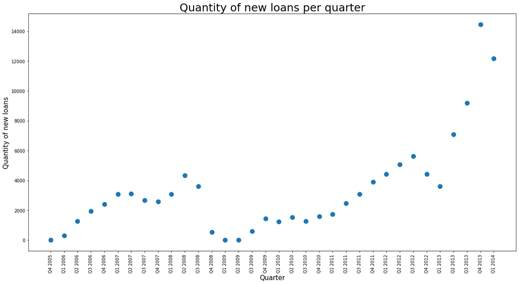

For now, let's check **what was the objective for these loans**.  
The main use appointed by borrowers for the new loans is to pay off other debts. This doesn't seem very good for the business, because Prosper and the fund investors need to receive their money back with all the interests. This should mean that Prosper does a very good job sorting good payers that are in debt from bad payers that are in debt.

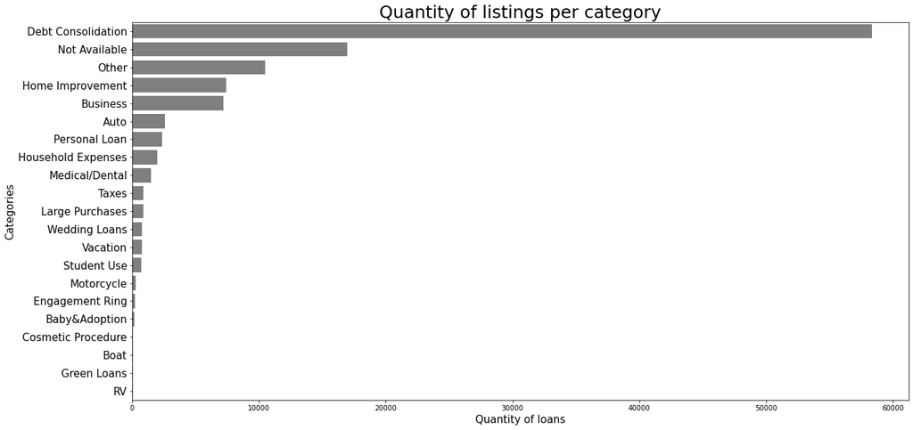

Now, let's take a look at the **Credit Grade for each borrower**.  
So for the loans that do have a rating, it seems that the majority of borrowers is normally distributed around the 'C' grade. Probably Prosper denies borrowers with very bad rating or only allow a certain amount of them into their platform.

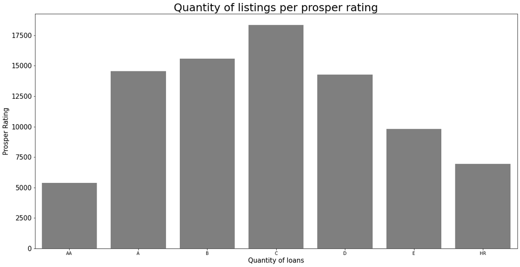

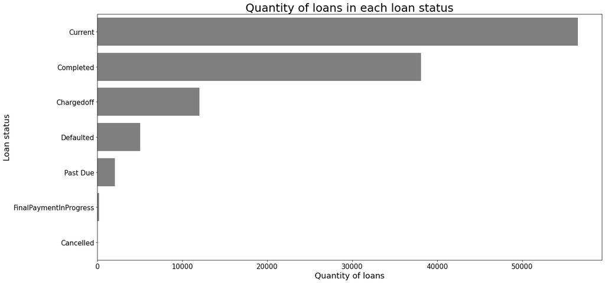

Finally, let's take a look at the **bankcard credit available to the borrowers**.  
Using a log scale, we can see that most of the borrowers have a fairly low credit available at their bankcard, with more than 50% below USD 10k.

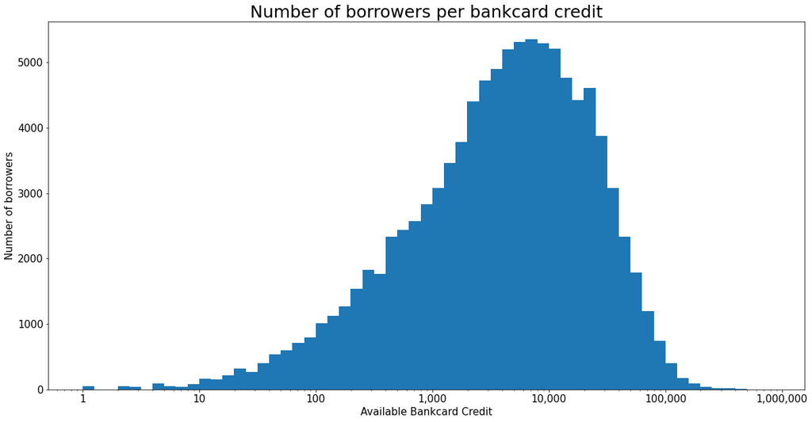

### Discuss the distribution(s) of your variable(s) of interest. Were there any unusual points? Did you need to perform any transformations?

> The dataset has presented two different behaviours regarding the number of new loans from each quarter: it is clear that there is some increase on the number of new loans between Q4 2005 and Q1 2013, but from Q2 2013 to Q1 2014 the quantity of new loans has skyrocketed. Some [news found online](https://www.lendacademy.com/p2p-lenders-2013-loan-volume/) also point to the fact that 2013 was a great year for Prosper. Also, the main use appointed by borrowers for the new loans is to pay off other debts. Although it seems to be bad news for Prospers business model, the company seems to do a very good job sorting good payers that are in debt from bad payers that are in debt. As we saw, for the loans that had the `ProsperRating` feature, it presents a normal curve shape around the 'C' grading, indicating that probably Prosper denies borrowers with very bad rating or only allow a certain amount of them into their platform. It was also possible to see that most loans are still ongoing and very few of them are past due. The borrowers bankcard credit is also low on its majority, below USD 10k.

### Of the features you investigated, were there any unusual distributions? Did you perform any operations on the data to tidy, adjust, or change the form of the data? If so, why did you do this?

> Transformations via groupby or type changes (for classifications) were needed to enable some visualizations, but for the most part, the data was tidy and ready for use. For `BankcardCredit` the log scale was applied in order to facilitate the conclusions makig process.

## Bivariate Exploration

Let's start by taking a look at the **percentage of loans made for each category before and after Q2 2013**.  
The percentage of debt consolidation went really up, to more than 75% of the loans made by Prosper on or after Q2 2013. This is probably a consequence of business decisions to focus on this group and develop better controls for their acceptance (which can be seen by the amount of new ratings and scores that they developed on 2009). It must be said that the 'Not available' also droppes after Q2 2013, so a chunck of the difference from the percentage representatio from 'Debt consolidation' may come from there.

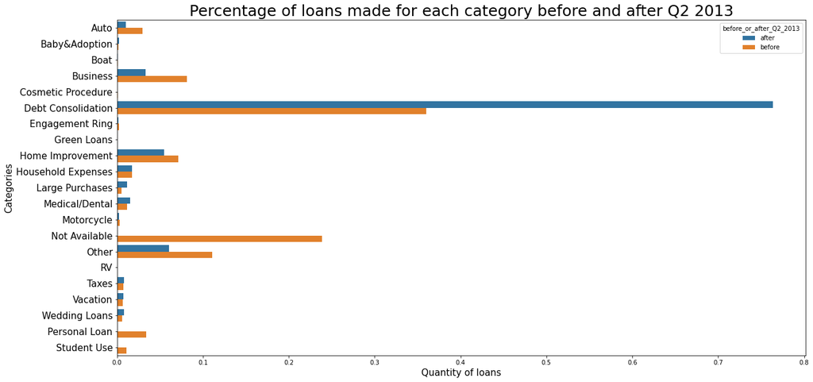

Let's also take a look at how the **Credit Grade behaves on these two timespawns**.  
It is noticeble that the amount of borrowers for grades D or below really changed over the two timespawns analyzed. Prosper was able to prospect borrowers with higher grades over the years and this represented a big change in the company.

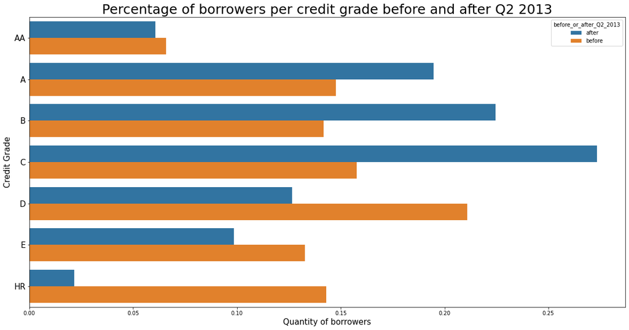

Let's check now the **behaviour of `ListingCategory` and `LoanStatus`. In some `ListingCategory` more harmful to the business?**  
Here we can see that the listing category is 'Debt Consolidation' doesn't present a higher percentage of Past dues. It is also noticeable that some listing categories, such as 'Personal Loan' and 'Student Use' have a very high percentage of completed loans, which indicate that this listing category was probably discontinued.

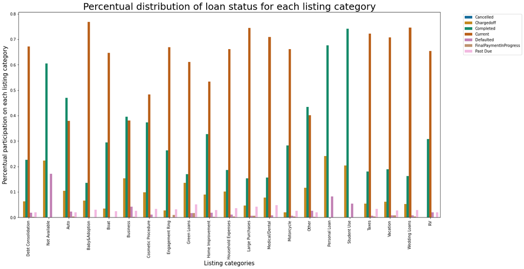

The **Borrower APR over time** may give us some additional perspective for Prospers business over time. Let's assess it **against the `LoanOriginationQuarter` feature**.  
The interquartile range is much smaller in the last quarters from this dataset, which also supports our hypothesis that Prosper has been developing internal controls to better refine the borrowers selection and the listings offer.

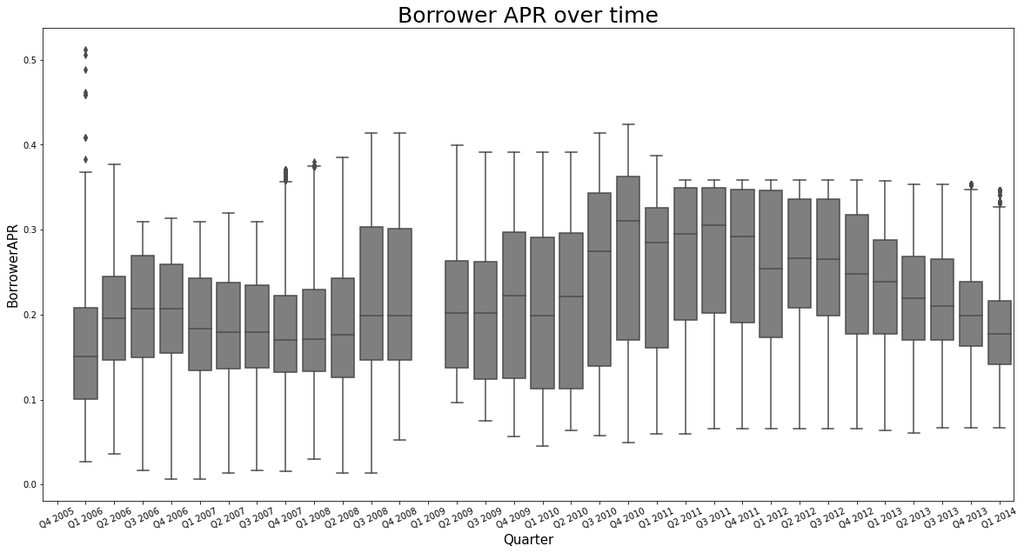

Let's see **if the `EstimatedReturn` has the same behaviour**.  
From the violin plot above, we can see that over the quarters, Prosper got more assertive about the estimated return for every loan.

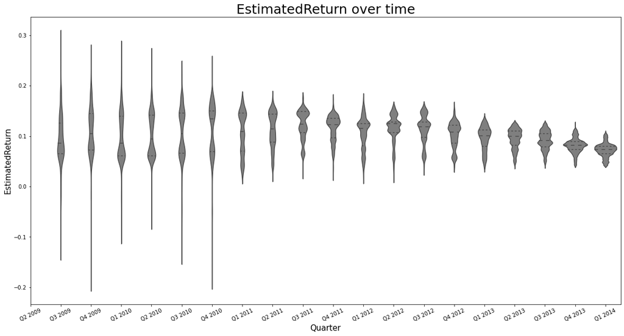

### Did you observe any interesting relationships between the other features (not the main feature(s) of interest)?

> Yes when observing the relationship between `BorrowerAPR` and `EstimatedReturn` over time.

## Multivariate Exploration

A very interesting analysis to be made is the `EstimatedReturn` against the `BorrowerAPR` for every `ProsperRating`.

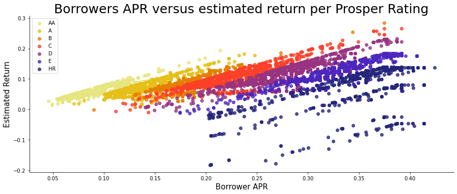

### Talk about some of the relationships you observed in this part of the investigation. Were there features that strengthened each other in terms of looking at your feature(s) of interest?

> So here we can see a clear relationship between risk (ProsperRating) and the expected return for each loan. It seems that Prospers AI suggests a BorrowersAPR of more than 20% for when they have a negative expected return, as a way of protecting the mean return.

### Were there any interesting or surprising interactions between features?

> Prosper has grown a lot in 2013 by refining its internal controls. These controls allowed Prosper to admit into its marketplace a higher amount of Borrowers that were good payers but were in debt. This fine balance was obtained by cross-checking a Prosper internal rating with the borrowers credit grade, in order to calculate the BorrowersAPR and EstimatedReturn. These features have a relationship among themselves that enable Prospers business to thrive!

[output not shown]